# DATA SCIENCE FOR BUSINESS PRGM - 2014-2015 Autumn

Author: Gene Leynes

Date: September 18, 2014

### How to learn R

“There are many like it, but this one is mine.” - from the Rifleman's Creed, Major General William H. Rupertus

There is a truly vast and ever growing growing body of literature dedicated to helping people learn R, however not all of the information is created equally.

- CRAN is always the maintainer of the R application and the default source of information: http://cran.r-project.org/
- Currently, R Studio is the best choice for code editing and project mangement http://www.rstudio.com/
- R has hundreds of user contributed libraries that you can install within R.

CRAN Specific resources:

- The R FAQs are invaluable: http://cran.r-project.org/faqs.html
- The statndard documentation is also invaluable: http://cran.r-project.org/manuals.html
- There are several “task views” that are very helpful for learning about R resources associated with particular tasks.
- You can access help right from R with “?”. For example, you can learn about the `lm` funciton by typing `?lm` at the console.
- CRAN resources and help can be very hard to understand, this is normal. Use many approaches to solve problems.
- Download and print this cheat sheet: http://cran.r-project.org/doc/contrib/Short-refcard.pdf
- See also http://cran.r-project.org/doc/contrib/Baggott-refcard-v2.pdf (this one is new to me)

### Where to get help

- Pay attention to *when* something was written, and to *who* wrote it. Some people seem to write guides as a way of learning themselves…
- Early R contributors really understand the internals, but their writings can be hard to understand.
- Newer R contributors tend to approach things from the perspective of their particular angle / set of packages
- Stack Overflow is a great place to find questions and answers if you get stuck. http://stackoverflow.com/questions/tagged/R
- I highly recommend Stack Overflow over the r-help mailing list.
- Many pacakges have vignettes which can be extremely helpful.

## Stackoverflow posting guide:

[figure not shown]

source: http://www.xkcd.com/627/

### Standing on the shoulders of giants

### Best Guides:

My favorite R resources for quick help:

- http://www.cookbook-r.com/
- http://www.r-statistics.com/

If you have experienced a singularity and have near infinite time to think:

- http://www.r-bloggers.com/
- http://cran.r-project.org/doc/contrib/
- http://cran.r-project.org/doc/contrib/usingR.pdf
- http://cran.r-project.org/web/views/

### Best packages:

- `data.table` The data frame evolved.
  - http://cran.r-project.org/web/packages/data.table/vignettes/datatable-faq.pdf
- `ggplot2` Hadley's Grammar of graphics
  - http://ggplot2.org/
  - http://www.cookbook-r.com/Graphs/
- `caret` Max Kuhn's machine learning pacakge
  - http://topepo.github.io/caret/index.html
  - http://www.amazon.com/Applied-Predictive-Modeling-Max-Kuhn/dp/1461468485
- `knitr` Yihui Xie's report writing tool based on markdown
  - http://yihui.name/knitr/
  - http://rmarkdown.rstudio.com/
- `shiny` R Studio's jQuery powered application maker
  - http://shiny.rstudio.com/

### Big picture of R

**Things to install**

- R http://cran.r-project.org/
- RStudio http://www.rstudio.com/products/rstudio/download/
- git http://git-scm.com/downloads

**Things in R**

- Elements
- Vectors
- Matricies
- Data frames
- Lists
- Environments
- Functions

**Things in R that do things (mostly within R)**

- Scripts
- Projects
- Packages on CRAN (install.packages)
- Packages elsewhere (devtools)

**There are different ways to use R**

- Step through code
- Run a script at the command line
- Put things into functions (more like making software)

**Technical details**

- The PATH environmental variable
- Environmental variables
- You don't need admin rights to have a good time
- R was not written by pirates
- R was not written programmers either

### Start of a typical script

Because the environment is completely initialized, the result is reproducable.

```r
##------------------------------------------------------------------------------
## INITIALIZATION
##------------------------------------------------------------------------------
rm(list=ls())
gc()
library(geneorama)
detach_nonstandard_packages()
library(geneorama)
loadinstall_libraries(c("geneorama", "data.table", "reshape2", "Matrix"))

sourceDir("functions/")
op <- readRDS("data/op.Rds")  ## Default par
par(op)

##------------------------------------------------------------------------------
## Load data for vacant buildings and violations
##------------------------------------------------------------------------------
filepath1 <- "data/20140507/Building_Violations.Rds"
filepath2 <- "data/20140507/Building_Violations__VIOLATION_ORDINANCE.Rds"
filepath3 <- "data/20140507/Building_Violations__VIOLATION_ORDINANCE_dummy_matrix.Rds"

datBuild <- readRDS(filepath1)
VIOLATION_ORDINANCE <- readRDS(filepath2)
VIOLATION_ORDINANCE_DM <- readRDS(filepath3)

##------------------------------------------------------------------------------
## (describe next steps here...)
##------------------------------------------------------------------------------

## Typically this includes, data prep, analysis, saving results
```

### Typical Project's folder structure (more about this later)

## Project structure

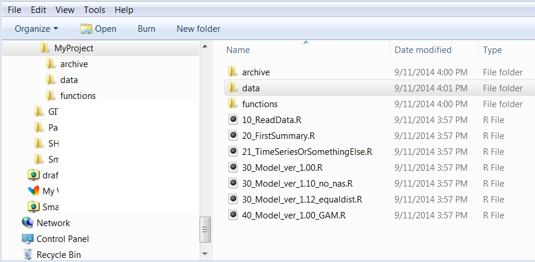

## Data Structure

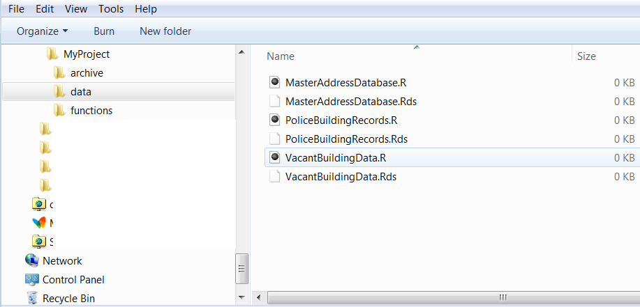

# Small Example

Topics: Assignment, variables, functions, random number generation, factors, comments, vectors

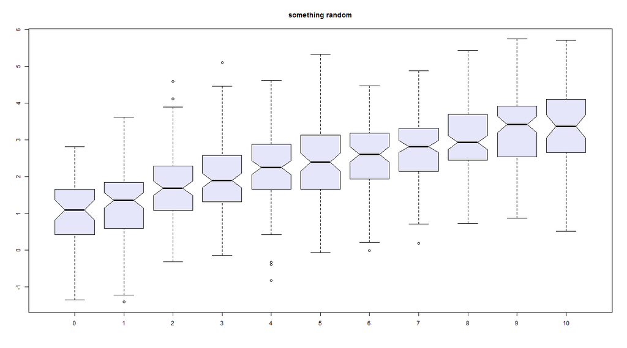

```r
rm(list=ls())

## Boxplot Example with gl
g <- factor(round(10 * runif(10*100)))
x <- rnorm(10*100) + sqrt(as.numeric(g))

boxplot(x~g, col='lavender', notch=T, var.width=T,
        main = "something random")
```

# `ggplot` (Grammar of graphics) Example

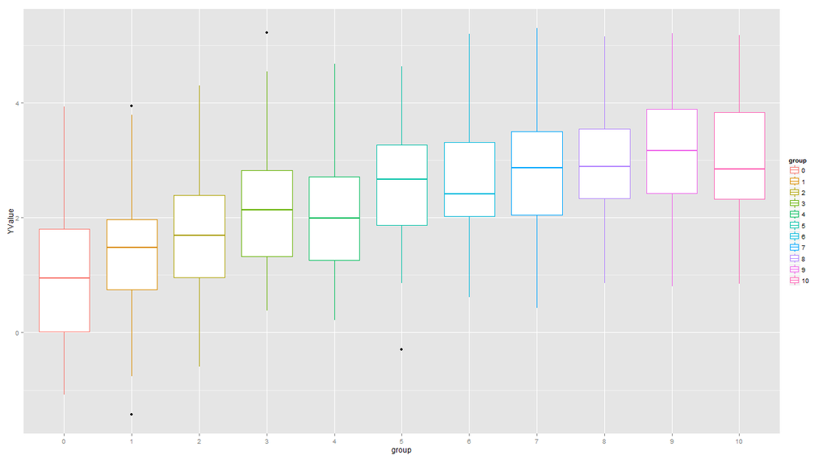

```r
rm(list=ls());library(data.table);library(ggplot2);
## Generate some data:
MyData <- data.table(group = factor(round(10 * runif(10*100))))
MyData[ , YValue := rnorm(10*100) + sqrt(as.numeric(group))]
## GGplot code:
ggplot(MyData) + aes(x=group, y=YValue, color=group) +
    geom_boxplot()
```

```r
# ggplot(MyData) + aes(x=group, y=YValue, color=group) +
#   geom_point()
```

# Tsay Time Series book cover

Topics: How to untangle code

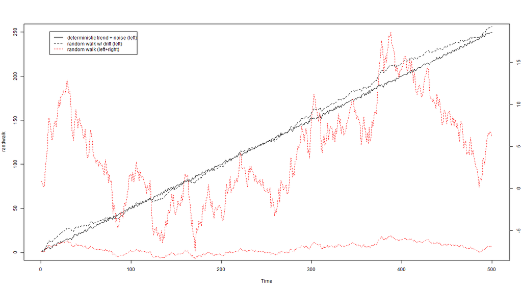

```r
# Make two plots on the same canvas # Legend # Random walk  # Tsay book cover
set.seed(123456)
e <- rnorm(500)           ## White noise
randwalk <- cumsum(e)     ## Random walk
trend <- 1:500            ## Trend
plot.ts(0.5 * trend + e, lty=1, ylab='', xlab='')  ## deterministic trend + noise
lines(0.5 * trend + cumsum(e), lty=2)              ## random walk with drift
lines(randwalk, lty=3, col='red')                  ## random walk (same scale)
par(new=T)
plot.ts(randwalk, lty=3, axes=FALSE, col='red')    ## random walk (own scale)
axis(4, pretty(range(randwalk)))
legend(10, 18.7, legend=c('deterministic trend + noise (left)',
                          'random walk w/ drift (left)', 'random walk (left+right)'),
       lty=c(1, 2, 3), col=c('black', 'black', 'red'))
```

# Tsay Time Series book cover (plot from previous slide)

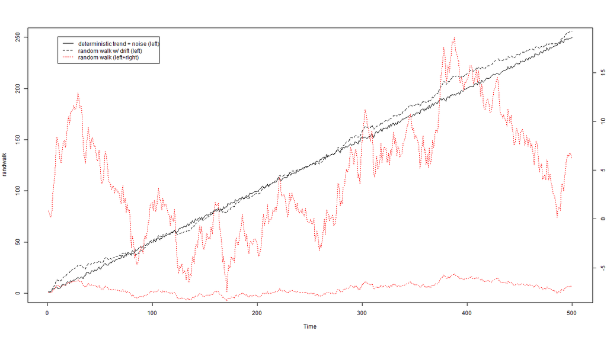

# Source Control using git

I *highly* recommend that you avoid using a GUI for git.

The ruby on rails book has an excellent and concise description of how to use git

- https://www.railstutorial.org/book/beginning#sec-version_control source: RUBY ON RAILS TUTORIAL - Learn Rails by Example by Michael Hartl

The website that hosts git also host the best documentation on git.

- http://git-scm.com/

Also, github has excellent documentation, especially on technical issues like RSA keys and ssh access.

- https://github.com/

Github uses git, but they are not the same things! People seem to think that github is git. Github is a host (probably the best host) were people can share git repositories.

https://github.com/  
https://github.com/geneorama/ <<- me

## File comparison

It's important to have a good way to compare and merge files. My preferred solution is Winmerge, but you can find many other programs online

- http://winmerge.org/